# R Notebook

# Packages

```r
library(ggplot2)
library(readr)
library(data.table)
library(ggthemes)
library(reshape)
library(forcats)
library(tidyverse)
library(ggrepel)
library(gcookbook)
```

# 1. Hotdog case

## Load the data

```r
setwd("/Users/hanxiao/Downloads/EmoryU/Fall/Data Visualization/2 Perception, Cognition & Viz Best Practices")
data = fread("hot-dog-contest-winners.csv")

# Columns: Year, Winner, DogsEaten, Country, NewRecord
```

## Draw the plot

1. If: “stat_count() can only have an x or y aesthetic.”, it means we need to use geom_bar(*stat = “identity”*). 必要时在geom_line()里写“density”。

但是！如果这是一个geom_histogram()这种只有一个变量的函数，就不能用stat，而是geom_histogram(alpha=0.4, *position=“identity”*)

**Color**

2. Then: 填充：if the bar is lined by color (in aes(), color = NewRecord) but the entire color is still grey. use *fill* = NewRecord in aes().
3. Then: if it is constant, but we want to use categorical variables use fill = *factor(NewRecord)* in aes().
4. Then: different color so it goes: *scale_fill_manual(“legend标题”, values = c(color, color), labels = c(“名字”, “名字”))*.
5. Then: hide the legend using *scale_fill_manual(values = c(color, color), guide = “none”)*. Not guided!! R recommended to use “none” instead of FALSE in *guide =* .

**axis**

6. x-axis数字分布
- scale_x_continuous(*“坐标轴名”, breaks = seq(起始, 终点, 间隔), limits = c(起始，终点)*)

y轴同理

**标题、副标题、尾注**

- labs(title = 标题, subtitle = 副标题（用斜杠n换行）, *caption = 右下角尾注*)

**加小字和竖线**

annotate(“text”, label = “In 2001, Takeru Kobayashi gets his first win in the competition. He went on to win five more years in a row.”, x = 1995, y = 62, size = 3, family = “Georgia”, hjust = 0, lineheight = 1) + annotate(“segment”, x = 2001, y = 56, xend = 2001, yend = 50, size = 0.5)

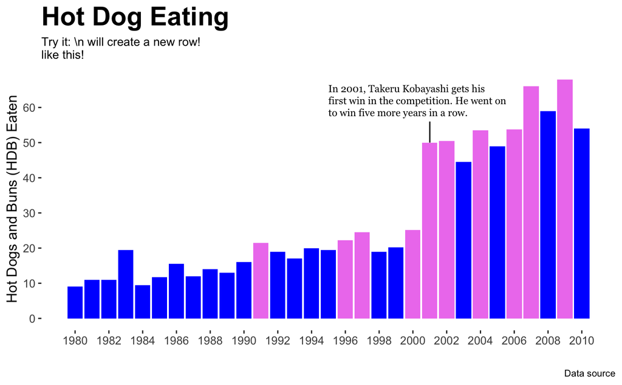

# 2. Stacked Bar Chart - Obama Approval Ratings

## Load the data

```r
data$id <- seq.int(nrow(obama))
```

[output not shown]

## Draw the plot

**Change the order in the legend**

Use *levels()* in aes().

**Change the name of the labels**

Use *labels = ()* in scale_fill_manual().

**x and y axis**

If we want to change y from 0, 0.1, 0.2…1.0 to 0%, 10%, …100%, here it goes: scale_y_continuous("", *labels=scales::percent*, breaks=seq(0, 1, by=0.1))

**坐标轴每个标签的方向**

theme(axis.test.x = element_text(angle = 45, hjust = 1), legend.position = “right”, legend.direction = “vertical”)

**打印大于15%的数字作为每个bar的标签**

- geom_text(aes(label=ifelse(Percentage >=0.15, paste(sprintf(“%.0f”, Percentage*100)),"“)), position=position_stack(vjust=0.5), color=”white")

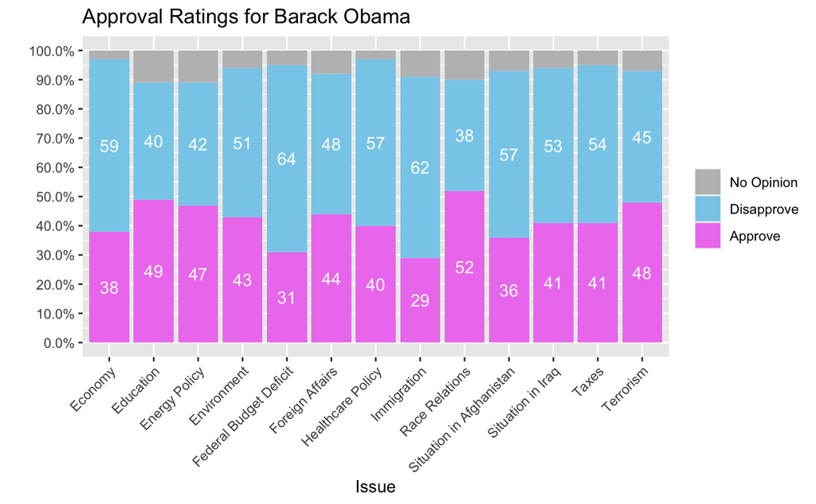

# 3. Trendlines in ggplot2 - Unemployment

## Load the data

```r
data = read.csv("http://datasets.flowingdata.com/unemployment-rate-1948-2010.csv", sep=",")

# Columns: Series.id, Year, Period, Value

data$Month <- as.numeric(gsub('M', '', data$Period))
data$Date <- as.yearmon(paste(data$Year, data$Month), "%Y %m")
```

## Draw the plot

**把实心点变成空心点，并且改变颜色**

geom_point(color = “颜色”, *shape = 1*)

**注意时间也是连续变量，所以用scale_x_continuous**

**即使我们用了breaks = seq(0,11,1)，y轴的最低点仍然不是0，所以要这样设置**

- expand_limits(y = 0)

**如果想把灰色背景去掉**

- theme_light()

**画线性回归的直线**

用*+ geom_smooth(method = “lm”, se=FALSE, color=“navy”)*

**其他回归模型

平滑曲线：geom_smooth(*method=“loess”*, se=FALSE, *span = 0.35*, color=“navy”)

省略span时，它是一个degree为2的polynomial model。

更平滑的曲线，y的x二次方程：geom_smooth(*method=“lm”, formula = y ~ poly(x, 2)*, color=“navy”)

**加上模型的方程**

用annotate(“label”, size=3, color=“颜色”, x = 中心点的x位置, y = 中心点的y位置, label.size=0, label = paste(“y =”,signif(reg$coef[[1]],5 ), "+ ", signif(reg$coef[[2]], 5), “x,”, " AdjR2 = ", signif(summary(reg)$adj.r.squared, 5))) 【背吧。】

```r
p =
ggplot(data, aes(x = Date, y = Value)) +
  geom_point(color = "red", shape = 1) +
  scale_y_continuous("Percent of Unemployed Americans", breaks = seq(0,11,1)) +
  scale_x_continuous("", breaks = seq(1945, 2010, 5)) +
  expand_limits(y = 0) +
  theme_light() +
  labs(title = "US Unemployment Rate 1948-2010") +
  geom_smooth(method = "lm")

reg <- lm(data = data, Value ~ Date)

lm = p + geom_smooth(method = "lm", se=FALSE, color="navy")

lm + annotate("label", size=3, color="dark gray", x = 1995, y = 1, label.size=0, label = paste("y = ",signif(reg$coef[[1]],5 ),"+ ",signif(reg$coef[[2]], 5),"x,", " AdjR2 = ",signif(summary(reg)$adj.r.squared, 5)))
```

[output not shown]

# 4. Case: housing

## Load the data

```r
housing <- read_csv("landdata-states.csv")
hp2001Q1 <- filter(housing, Date == 2001.25)
```

## Draw the plot

**画点图时，加文字**

*+ geom_text_repel(aes(label = State), size = 3)* 注意别漏了repel

**改变不同的region的形状和颜色**

geom_point(aes(*color = Home.Value*, *shape = region*))

**画某个数值的直方分布图**

只用*一个*变量 ggplot(housing, aes(*x = Home.Value*))

- geom_histogram(binwidth = 每一条的宽度, col = 线条颜色, fill = 填充色, alpha = .2)

**用bar图画每个区域的平均值**

*两个*变量 ggplot(housing.sum, aes(*x = State, y = Home.Value*)) + geom_bar(stat = “identity”)

按照年份设置颜色：

scale_color_continuous(name = "“, breaks = c(1976, 1994, 2013), labels = c(”76“,”94“,”13“), low =”blue“, high =”red")

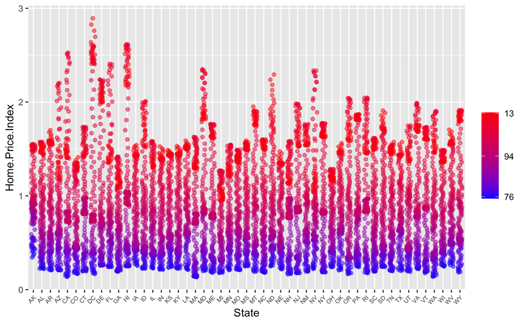

# 5. Faceting

## Draw the plot

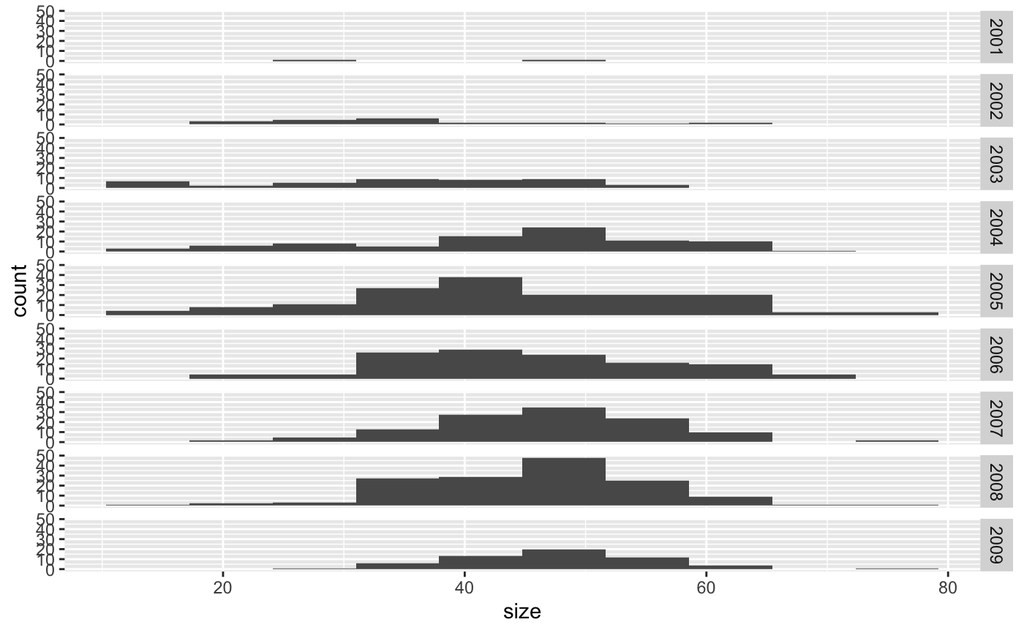

# 密度分布图和提琴图

## Load the data

**频次直方图** geom_histogram(alpha = .5)

**密度图** geom_density(alpha = .5)

**提琴图里的注意事项** 1. 在aes()里用factor()和对应的平均数或者其他指标； 2. 在geom_violin里再写一次*aes(fill = lg)*； 3. 写*+ geom_jitter()* 把点点也都加上。

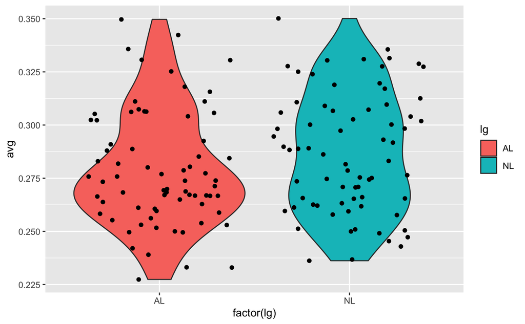

# ECDF

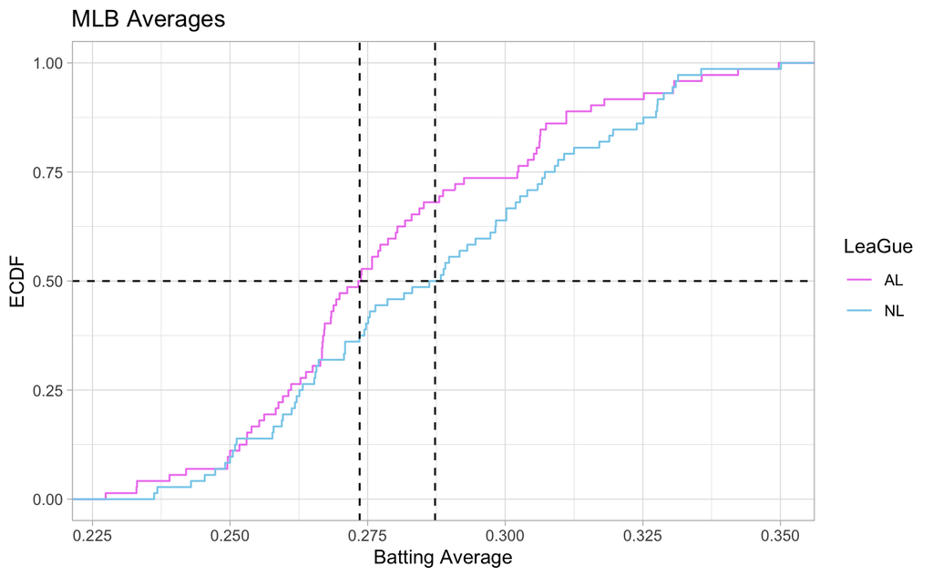

```r
library(ggbeeswarm)

ggplot(tophitters2001, aes(avg)) +
  stat_ecdf(geom = "step", aes(color = lg)) +
  scale_y_continuous("ECDF", breaks = seq(0,1,0.25)) +
  scale_x_continuous("Batting Average") +
  scale_color_manual("LeaGue", values = c("violet", "sky blue")) +
  labs(title = "MLB Averages") +
  theme_light() +
  geom_hline(yintercept = 0.5, linetype = "dashed") +
  geom_vline(data = subset(tophitters2001, lg == "NL"), aes(xintercept = quantile(avg)[3]), linetype = "dashed") +
  geom_vline(data = subset(tophitters2001, lg == "AL"), aes(xintercept = quantile(avg)[3]), linetype = "dashed")
```